# YFCC100m visualization based on 100x100km grid (Mollweide)

# Introduction

Based on data from YFCC100m dataset, this Notebook explores a processing example for visualizing frequentation patterns in a 100x100km Grid (worldwide). The data used here was converted from YFCC CSVs to the [raw lbsn structure](https://gitlab.vgiscience.de/lbsn/databases/rawdb) using [lbsntransform](https://lbsn.vgiscience.org/lbsntransform/docs/) package.

Our goal was to illustrate a complete typical visualization pipeline, from reading data to processing to visualization. There're additional steps included such as archiving intermediate results or creating an alternative interactive visualization.

This is the second notebook in a series of four notebooks:

- 1) the Preparations (01_preparations.ipynb) Preparations for importing and pre-processing YFCC100m.
- 2) the RAW Notebook (02_yfcc_gridagg_raw.ipynb) demonstrates how a typical grid-based visualization looks like when using the **raw** lbsn structure and
- 3) the HLL Notebook (03_yfcc_gridagg_hll.ipynb) demonstrates the same visualization using the privacy-aware **hll** lbsn structure
- 4) the Interpretation (04_interpretation.ipynb) illustrates how to create interactive graphics for comparison of raw and hll results; intersection of published data.

In this Notebook, we describe a complete visualization pipeline, exploring worldwide frequentation patterns from YFCC dataset based on a 100x100km grid. The following steps are some of the parts explained:

- get data from LBSN raw db (PostgreSQL select)
- store raw data to CSV, load from CSV
- create a parametrized world-wide grid
- implement a binary search for fast mapping of coordinates to grid-bins
- perform the bin-assignment with actual coordinates from Flickr YFCC dataset
- chunk processing into smaller parts, to reduce memory load
- summarize different metrics for bins: postcount, usercount, userdays
- create methods to reduce from individual code parts
- measure timing of different steps, to compare processing time with hll-dataset approach
- load and store intermediate results from and to *.pickle and *.CSV

**System requirements**

The raw notebook requires about **16 GB of Memory**, the hll notebook about 8 GB.

**Additional notes:**

Use **Shift+Enter** to walk through the Notebook

# Preparations

## Parameters

This is a collection of parameters that affect processing and graphics.

```python
from pathlib import Path

GRID_SIZE_METERS = 100000 # the size of grid cells in meters
                          # (spatial accuracy of worldwide measurement)
# process x number of hll records per chunk.
# Increasing this number will consume more memory,
# but reduce processing time because less SQL queries
# are needed.
CHUNK_SIZE = 5000000
# target projection: Mollweide (epsg code)
EPSG_CODE = 54009
# note: Mollweide defined by _esri_
# in epsg.io's database
CRS_PROJ = f"esri:{EPSG_CODE}"
# Input projection (Web Mercator)
CRS_WGS = "epsg:4326"
# define path to output directory (figures etc.)
OUTPUT = Path.cwd().parents[0] / "out"
```

## Load dependencies

Load all dependencies at once, as a means to verify that everything required to run this notebook is available.

```python
import os
import csv
import sys
import math
import colorcet
import psycopg2
import holoviews as hv
import mapclassify as mc
import geopandas as gp
import pandas as pd
import numpy as np
import matplotlib.pyplot as plt
from pathlib import Path
from typing import List, Tuple, Dict, Union, Generator, Optional
from pyproj import Transformer, CRS, Proj
from geoviews import opts
from shapely.geometry import shape, Point, Polygon
from shapely.ops import transform
from cartopy import crs
from matplotlib import colors
from IPython.display import clear_output, display, HTML, Markdown
# optionally, enable shapely.speedups
# which makes some of the spatial
# queries running faster
import shapely.speedups as speedups
speedups.enable()
```

Load helper module from `../py/module/tools.py`. This also allows to import code from other jupyter notebooks, synced to `*.py` with jupytext.

```python
module_path = str(Path.cwd().parents[0] / "py")
if module_path not in sys.path:
    sys.path.append(module_path)
from modules import tools, preparations
```

Set pandas colwidth.

```python
pd.set_option('display.max_colwidth', 25)
```

Activate autoreload of changed python files:

```python
%load_ext autoreload
%autoreload 2
```

Load memory profiler extension

```python
%load_ext memory_profiler
```

Plot used package versions for future use:

•••

| package | xarray | Shapely | pyproj | pandas | numpy | matplotlib | mapclassify | ipython | holoviews | geoviews | geopandas | Fiona | Cartopy | bokeh |
| --- | --- | --- | --- | --- | --- | --- | --- | --- | --- | --- | --- | --- | --- | --- |
| version | 0.16.1 | 1.7.1 | 2.6.1.post1 | 1.1.2 | 1.19.1 | 3.3.2 | 2.3.0 | 7.18.1 | 1.13.4 | 1.8.1 | 0.8.1 | 1.8.17 | 0.18.0 | 2.2.1 |

### Connect to database

Password is loaded from `.env` file specified in container setup hlldb.

The docker stack contains a full backup of the YFCC database converted to the privacy-aware datastructure. In this Notebook, we're only working with a small part of the data from the table `spatial.latlng`.

Define credentials as environment variables

```python
db_user = "postgres"
db_pass = os.getenv('POSTGRES_PASSWORD')
# set connection variables
db_host = "rawdb"
db_port = "5432"
db_name = "rawdb"
```

Connect to empty Postgres database running HLL Extension. Note that only `readonly` privileges are needed.

```python
db_connection = psycopg2.connect(
        host=db_host,
        port=db_port,
        dbname=db_name,
        user=db_user,
        password=db_pass
)
db_connection.set_session(readonly=True)
```

Test connection:

```python
db_query = """
    SELECT 1;
"""
# create pandas DataFrame from database data
df = pd.read_sql_query(db_query, db_connection)
display(df.head())
```

|  | ?column? |
| --- | --- |
| 0 | 1 |

For simplicity, the db connection parameters and query are stored in a class:

```python
db_conn = tools.DbConn(db_connection)
db_conn.query("SELECT 1")
```

|  | ?column? |
| --- | --- |
| 0 | 1 |

## LBSN structure data introduction

The [Location Based Social Network (LBSN) structure](https://lbsn.vgiscience.org/) was developed as a standardized conceptual data model for analyzing, comparing and relating information of different LBSN in visual analytics research and beyond. The primary goal is to systematically characterize LBSN data aspects in a common scheme that enables privacy-by-design for connected software, data handling and information visualization.

**Modular design**

The core lbsn structure is described in a platform independent [Protocol Buffers](https://developers.google.com/protocol-buffers/) file. The [Proto file](https://gitlab.vgiscience.de/lbsn/structure/protobuf/) can be used to compile and implement the proposed structure in any language such as Python, Java or C++.

This structure is tightly coupled with a relational datascheme (Postgres SQL) that is maintained [separately](https://gitlab.vgiscience.de/lbsn/structure/rawdb/), inluding a [privacy-aware version](https://gitlab.vgiscience.de/lbsn/structure/hlldb/) that can be used for visualization purposes. The database is ready to use with several provided [Docker containers](https://gitlab.vgiscience.de/lbsn/tools/full-stack-lbsn) that optionally include a PGadmin interface.

A documentation of the LBSN structure components is available at https://lbsn.vgiscience.org/structure/.

First, some statistics for the data we're working with.

Note that the following two queries take about 10 Minutes each. They're not necessary to run the notebook.

```python
%%time
db_query = """
    SELECT count(*) FROM topical.post;
"""

display(Markdown(
    f"There're "
    f"<strong style='color: red;'>"
    f"{db_conn.query(db_query)['count'][0]:,.0f}</strong> "
    f"distinct records (Flickr photo posts) in this table."))
```

There're **100,000,000** distinct records (Flickr photo posts) in this table.

```
CPU times: user 24.5 ms, sys: 18.2 ms, total: 42.6 ms
Wall time: 6min 31s
```

The Flickt YFCC 100M dataset includes 99,206,564 photos and 793,436 videos from 581,099 different photographers, and 48,469,829 of those are geotagged [[1]](https://code.flickr.net/category/geo/).

Photos are available in schema `topical` and table `post`.

With a query `get_stats_query` defined in `tools` module, we can get a more fine grained output of statistics for this table:

```python
%%time
db_query = tools.get_stats_query("topical.post")
stats_df = db_conn.query(db_query)
stats_df["bytes/ct"] = stats_df["bytes/ct"].fillna(0).astype('int64')
display(stats_df)
```

|  | metric | bytes/ct | bytes_pretty | bytes_per_row |
| --- | --- | --- | --- | --- |
| 0 | core_relation_size | 48428793856 | 45 GB | 484.0 |
| 1 | visibility_map | 0 | 0 bytes | 0.0 |
| 2 | free_space_map | 11919360 | 11 MB | 0.0 |
| 3 | table_size_incl_toast | 49340284928 | 46 GB | 493.0 |
| 4 | indexes_size | 26507223040 | 25 GB | 265.0 |
| 5 | total_size_incl_toast_and_indexes | 75847507968 | 71 GB | 758.0 |
| 6 | live_rows_in_text_representation | 42719824906 | 40 GB | 427.0 |
| 7 | ------------------------------ | 0 | None | NaN |
| 8 | row_count | 100000000 | None | NaN |
| 9 | live_tuples | 0 | None | NaN |
| 10 | dead_tuples | 0 | None | NaN |

```
CPU times: user 60.7 ms, sys: 41.3 ms, total: 102 ms
Wall time: 13min 37s
```

```python
db_query = "SELECT * FROM topical.post WHERE post_geoaccuracy != 'unknown' LIMIT 5;"
first_10_df = db_conn.query(db_query)
display(first_10_df)
```

|  | origin_id | post_guid | post_latlng | place_guid | city_guid | country_guid | user_guid | post_publish_date | post_body | post_geoaccuracy | ... | post_url | post_type | post_filter | post_quote_count | post_share_count | post_language | input_source | user_mentions | modified | post_content_license |
| --- | --- | --- | --- | --- | --- | --- | --- | --- | --- | --- | --- | --- | --- | --- | --- | --- | --- | --- | --- | --- | --- |
| 0 | 2 | 6985418911 | 0101000020E61000009F02603C837354C0198D7C5EF18C... | 56558566 | 12772085 | 56043648 | 39089491@N00 | 2012-03-15 20:41:23 | None | place | ... | http://www.flickr.com/photos/39089491@N00/6985... | image | None | None | None | None | None | [] | 2020-02-15 05:09:05.922172 | 3 |
| 1 | 2 | 10201275523 | 0101000020E6100000494DBB9866D753C08BF9B9A129D3... | 55855853 | 12697691 | 56043697 | 55289779@N00 | 2013-10-11 06:10:28 | None | latlng | ... | http://www.flickr.com/photos/55289779@N00/1020... | image | None | None | None | None | None | [] | 2020-02-15 05:09:05.922172 | 5 |
| 2 | 2 | 7289030198 | 0101000020E6100000C7D79E59127F52C0A7ECF483BA5E... | 28751381 | 12761347 | 56043648 | 53430201@N03 | 2012-05-28 21:26:39 | None | latlng | ... | http://www.flickr.com/photos/53430201@N03/7289... | image | None | None | None | None | None | [] | 2020-02-15 05:09:05.922172 | 3 |
| 3 | 2 | 4572998878 | 0101000020E6100000EC1516DC0FC351C0E544BB0A292B... | 2496012 | 12758726 | 56043648 | 78969707@N00 | 2010-05-03 01:37:20 | Greeny's, Christines, Andy, Jeeane and Lou's p... | latlng | ... | http://www.flickr.com/photos/78969707@N00/4572... | image | None | None | None | None | None | [] | 2020-02-15 05:09:05.922172 | 3 |
| 4 | 2 | 3973434963 | 0101000020E6100000D20149D8B793D8BFD670917BBABC... | 20220221 | 20080321 | 56043644 | 71322403@N00 | 2009-10-02 11:04:00 | None | latlng | ... | http://www.flickr.com/photos/71322403@N00/3973... | image | None | None | None | None | None | [] | 2020-02-15 05:09:05.922172 | 1 |

5 rows × 28 columns

### Get data from db and write to CSV

To [speed up processing](https://stackoverflow.com/questions/43874559/pandas-is-faster-to-load-csv-than-sql/50876534#50876534) in this notebook, we're going to work on a CSV file instead of live data retrieved from the database. The yfcc raw db contains many attributes, for the visualization and metrics used in this notebook, we only need the following attributes:

- latitude and longitude coordinates of geotagged yfcc photos, to bin coordinates to the grid and counting number of posts
- the user_guid, to count distinct users
- the date of photo creation, to count distinct userdays

To make processing of raw data comparable to hll data processing, we're also reducing the accuracy of lat/lng coordinates with a GeoHash Precision of 5 to about 4 km spatial accuracy. Similarly, we reduce temporal granularity to dates, because time is not needed for measuring userdays. Such considerations benefit both privacy and ease of processing.

```python
def get_yfccposts_fromdb(
        chunk_size: int = CHUNK_SIZE) -> List[pd.DataFrame]:
    """Returns YFCC posts from db"""
    sql = f"""
    SELECT  ST_Y(ST_PointFromGeoHash(ST_GeoHash(t1.post_latlng, 5), 5)) As "latitude",
            ST_X(ST_PointFromGeoHash(ST_GeoHash(t1.post_latlng, 5), 5)) As "longitude",
            t1.user_guid,
            to_char(t1.post_create_date, 'yyyy-MM-dd') As "post_create_date"
    FROM topical.post t1
    WHERE
    NOT ((ST_Y(t1.post_latlng) = 0) AND (ST_X(t1.post_latlng) = 0))
    AND
    t1.post_geoaccuracy IN ('place', 'latlng', 'city');
    """
    # execute query, enable chunked return
    return pd.read_sql(sql, con=db_connection, chunksize=chunk_size)

def write_chunkeddf_tocsv(
    filename: str, usecols: List[str], chunked_df: List[pd.DataFrame],
    chunk_size: int = CHUNK_SIZE, output: Path = OUTPUT):
    """Write chunked dataframe to CSV"""
    for ix, chunk_df in enumerate(chunked_df):
        mode = 'a'
        header = False
        if ix == 0:
            mode = 'w'
            header = True
        chunk_df.to_csv(
            output / "csv" / filename,
            mode=mode, columns=usecols,
            index=False, header=header)
        clear_output(wait=True)
        display(
            f'Stored {(ix*chunk_size)+len(chunk_df)} '
            f'posts to CSV..')
```

The sql explained:

```
SELECT  ST_Y(ST_PointFromGeoHash(ST_GeoHash(t1.post_latlng, 5), 5)) As "latitude",  -- lat and long coordinates from
        ST_X(ST_PointFromGeoHash(ST_GeoHash(t1.post_latlng, 5), 5)) As "longitude", -- PostGis geometry, with GeoHash 5
        t1.user_guid,                                                    -- the user_guid from Flickr (yfcc100m)
        to_char(t1.post_create_date, 'yyyy-MM-dd') As "post_create_date" -- the photo's date of creation, without time,
                                                                         -- to count distinct days
FROM topical.post t1                                                     -- the table reference from lbsn raw:
                                                                         -- scheme (facet) = "topical", table = "post"
WHERE
NOT ((ST_Y(t1.post_latlng) = 0) AND (ST_X(t1.post_latlng) = 0))          -- excluding Null Island
AND
t1.post_geoaccuracy IN ('place', 'latlng', 'city');                      -- lbsn raw geoaccuracy classes,
                                                                         -- equals Flickr geoaccuracy levels 8-16*
```

* The maximum resolution for maps will be 50 or 100km raster, therefore 8 (==`city` in lbsn raw structure) appears to be a reasonable choice. Also see [Flickr yfcc to raw lbsn mapping](https://gitlab.vgiscience.de/lbsn/lbsntransform/blob/master/lbsntransform/classes/field_mapping_yfcc100m.py#L343)

**Execute query:**

```python
%%time
filename = "yfcc_posts.csv"
usecols = ["latitude", "longitude", "user_guid", "post_create_date"]
if Path(OUTPUT / "csv" / filename).exists():
        print(f"CSV already exists, skipping load from db..")
else:
    write_chunkeddf_tocsv(
        chunked_df=get_yfccposts_fromdb(),
        filename=filename,
        usecols=usecols)
```

```
'Stored 47843599 posts to CSV..'
```

```
CPU times: user 7min 45s, sys: 38 s, total: 8min 23s
Wall time: 18min 55s
```

**RAW file size:**

```python
raw_size_mb = Path(OUTPUT / "csv" / "yfcc_posts.csv").stat().st_size / (1024*1024)
print(f"Size: {raw_size_mb:.2f} MB")
```

```
Size: 2494.16 MB
```

### RAW Questions

To anticipate some questions or assumptions:

**Why do I need a DB connection to get yfcc data, the original yfcc files are available as CSV?**

> YFCC original CSVs are formatted in a custom format. LBSN raw structure offers a systematic data scheme for handling of Social Media data such as yfcc. The database also allows us to better illustrate how to limit the query to only the data that is needed.

## Create Grid

1. Define Mollweide crs string for pyproj/Proj4 and WGS1984 for Social Media imports

```python
# define Transformer ahead of time
# with xy-order of coordinates
PROJ_TRANSFORMER = Transformer.from_crs(
    CRS_WGS, CRS_PROJ, always_xy=True)

# also define reverse projection
PROJ_TRANSFORMER_BACK = Transformer.from_crs(
    CRS_PROJ, CRS_WGS, always_xy=True)
```

1. create bounds from WGS1984 and project to Mollweide

```python
XMIN = PROJ_TRANSFORMER.transform(
    -180, 0)[0]
XMAX = PROJ_TRANSFORMER.transform(
    180, 0)[0]
YMAX = PROJ_TRANSFORMER.transform(
    0, 90)[1]
YMIN = PROJ_TRANSFORMER.transform(
    0, -90)[1]
```

```python
print(f'Projected bounds: {[XMIN, YMIN, XMAX, YMAX]}')
```

```
Projected bounds: [-18040095.696147293, -9020047.848073646, 18040095.696147293, 9020047.848073646]
```

1. Create 100x100 km (e.g.) Grid

```python
def create_grid_df(
    grid_size: int = GRID_SIZE_METERS,
    xmin: float = XMIN,
    ymin: float = YMIN,
    xmax: float = XMAX,
    ymax: float = YMAX,
    report: bool = None,
    return_rows_cols: bool = None):
    """Creates dataframe polygon grid based on width and length in Meters"""
    width = grid_size
    length = grid_size
    cols = list(range(int(np.floor(xmin)), int(np.ceil(xmax)), width))
    rows = list(range(int(np.floor(ymin)), int(np.ceil(ymax)), length))
    if report:
        print(len(cols))
        print(len(rows))
    rows.reverse()

    polygons = []
    for x in cols:
        for y in rows:
            # combine to tuple: (x,y, poly)
            # and append to list
            polygons.append(
                (x, y,
                 Polygon([
                     (x, y),
                     (x+width, y),
                     (x+width, y-length),
                     (x, y-length)])))
    # create a pandas dataframe
    # from list of tuples
    grid = pd.DataFrame(polygons)
    # name columns
    col_labels=['xbin', 'ybin', 'bin_poly']
    grid.columns = col_labels
    # use x and y as index columns
    grid.set_index(['xbin', 'ybin'], inplace=True)
    if return_rows_cols:
        return grid, rows, cols
    return grid
```

```python
grid, rows, cols = create_grid_df(
    report=True, return_rows_cols=True)
```

```
361
181
```

```python
grid.head()
```

| xbin | ybin | bin_poly |
| --- | --- | --- |
| -18040096 | 8979952 | POLYGON ((-18040096 8... |
|  | 8879952 | POLYGON ((-18040096 8... |
|  | 8779952 | POLYGON ((-18040096 8... |
|  | 8679952 | POLYGON ((-18040096 8... |
|  | 8579952 | POLYGON ((-18040096 8... |

Create a geodataframe from dataframe:

```python
def grid_to_gdf(
    grid: pd.DataFrame, crs_proj: str = CRS_PROJ) -> gp.GeoDataFrame:
    """Convert grid pandas DataFrame to geopandas Geodataframe"""
    grid = gp.GeoDataFrame(
        grid.drop(
            columns=["bin_poly"]),
            geometry=grid.bin_poly)
    grid.crs = crs_proj
    return grid
```

```python
grid = grid_to_gdf(grid)
```

Add columns for aggregation

```python
def reset_metrics(
    grid: gp.GeoDataFrame,
    metrics: List[str] = ["postcount", "usercount", "userdays"], setzero: bool = None):
    """Remove columns from GeoDataFrame and optionally fill with 0"""
    for metric in metrics:
        try:
            grid.drop(metric, axis=1, inplace=True)
            grid.drop(f'{metric}_cat', axis=1, inplace=True)
        except KeyError:
            pass
        if setzero:
            grid.loc[:, metric] = 0
```

```python
reset_metrics(grid)
display(grid)
```

| xbin | ybin | geometry |
| --- | --- | --- |
| -18040096 | 8979952 | POLYGON ((-18040096.0... |
|  | 8879952 | POLYGON ((-18040096.0... |
|  | 8779952 | POLYGON ((-18040096.0... |
|  | 8679952 | POLYGON ((-18040096.0... |
|  | 8579952 | POLYGON ((-18040096.0... |
| ... | ... | ... |
| 17959904 | -8620048 | POLYGON ((17959904.00... |
|  | -8720048 | POLYGON ((17959904.00... |
|  | -8820048 | POLYGON ((17959904.00... |
|  | -8920048 | POLYGON ((17959904.00... |
|  | -9020048 | POLYGON ((17959904.00... |

65341 rows × 1 columns

**Read World geometries data**

```python
%%time
world = gp.read_file(gp.datasets.get_path('naturalearth_lowres'), crs=CRS_WGS)
world = world.to_crs(CRS_PROJ)
```

```
CPU times: user 354 ms, sys: 15.9 ms, total: 370 ms
Wall time: 368 ms
```

### Preview Grid

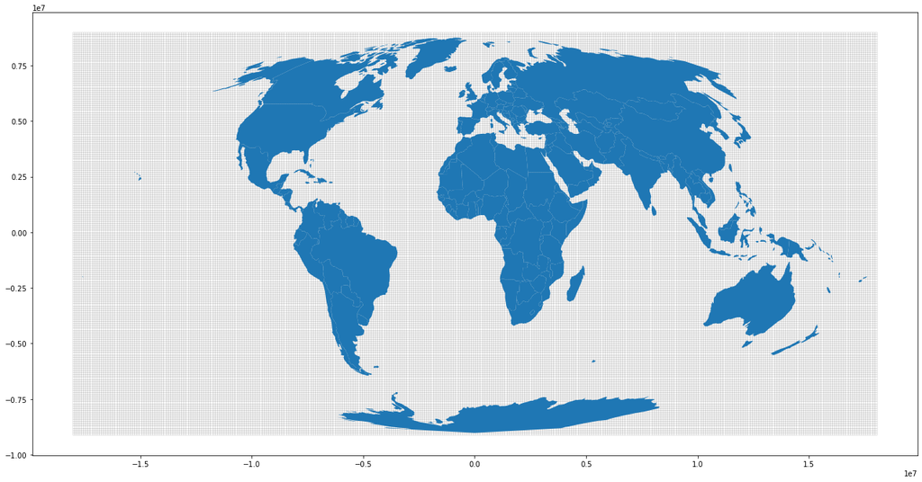

```python
base = grid.plot(figsize=(22,28), color='white', edgecolor='black', linewidth=0.1)
# combine with world geometry
plot = world.plot(ax=base)
```

# Prepare binary search

The aggregation speed is important here and we should not use polygon intersection. Since we're working with a regular grid and floating point numbers, a [binary search](https://en.wikipedia.org/wiki/Binary_search_algorithm) is likely one of the fastest ways for our context. [numpy.digitize](https://docs.scipy.org/doc/numpy/reference/generated/numpy.digitize.html) provides a binary search, but it must be adapted to for the spatial context. A lat or lng value is assigned to the nearest bin matching. We get our lat and lng bins from our original Mollweide grid, which are regularly spaced at 100km interval. Note that we need to do two binary searches, for lat and for lng values.

## Create test points

```python
testpoint = Point(8.546377, 47.392323)
testpoint2 = Point(13.726359, 51.028512)
gdf_testpoints = gp.GeoSeries([testpoint, testpoint2], crs=CRS_WGS)
# project geometries to Mollweide
gdf_testpoints_proj = gdf_testpoints.to_crs(CRS_PROJ)
```

```python
gdf_testpoints_proj[0].x
```

```
671646.5840955656
```

Preview map for testpoint

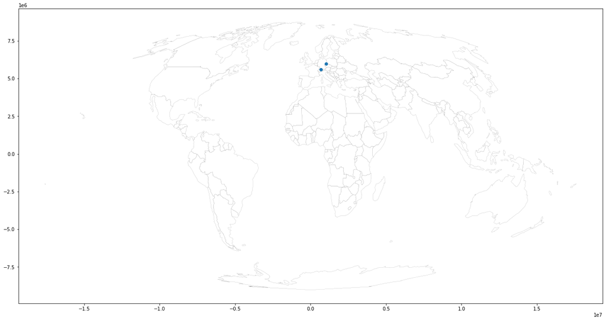

```python
base = world.plot(figsize=(22,28), color='white', edgecolor='black', linewidth=0.1)
plot = gdf_testpoints_proj.plot(ax=base)
```

### Use np.digitize() to assign coordinates to the grid

> [np.digitize](https://docs.scipy.org/doc/numpy/reference/generated/numpy.digitize.html) is implemented in terms of np.searchsorted. This means that a binary search is used to bin the values, which scales much better for larger number of bins than the previous linear search. It also removes the requirement for the input array to be 1-dimensional.

Create 2 bins for each axis of existing Mollweide rows/cols grid:

```python
ybins = np.array(rows)
xbins = np.array(cols)
```

Create 2 lists with a single entry (testpoint coordinate)

```python
test_point_list_x = np.array([gdf_testpoints_proj[0].x, gdf_testpoints_proj[1].x])
test_point_list_y = np.array([gdf_testpoints_proj[0].y, gdf_testpoints_proj[1].y])
```

Find the nearest bin for x coordinate (returns the bin-index):

```python
x_bin = np.digitize(test_point_list_x, xbins) - 1
display(x_bin)
```

```
array([187, 190])
```

```python
testpoint_xbin_idx = xbins[[x_bin[0], x_bin[1]]]
display(testpoint_xbin_idx)
```

```
array([659904, 959904])
```

Repeat the same for y-testpoint:

```python
y_bin = np.digitize(test_point_list_y, ybins) - 1
display(y_bin)
```

```
array([33, 29])
```

```python
testpoint_ybin_idx = ybins[[y_bin[0], y_bin[1]]]
display(testpoint_ybin_idx)
```

```
array([5679952, 6079952])
```

### Highlight Testpoint in Grid

Get grid-poly by index from testpoint

```python
grid.loc[testpoint_xbin_idx[0], testpoint_ybin_idx[0]]
```

```
geometry    POLYGON ((659904.000 ...
Name: (659904, 5679952), dtype: geometry
```

Convert shapely bin poly to Geoseries and plot

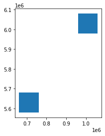

```python
testpoint_grids = gp.GeoSeries(
    [grid.loc[testpoint_xbin_idx[0], testpoint_ybin_idx[0]].geometry, grid.loc[testpoint_xbin_idx[1], testpoint_ybin_idx[1]].geometry])
testpoint_grids.plot()
```

### Preview map with testpoint and assigned bin

Set auto zoom with buffer:

```python
minx, miny, maxx, maxy = testpoint_grids.total_bounds
buf = 1000000
```

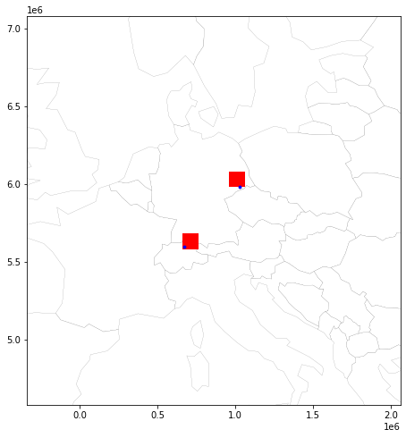

```python
# a figure with a 1x1 grid of Axes
fig, ax = plt.subplots(1, 1,figsize=(10,8))
ax.set_xlim(minx-buf, maxx+buf)
ax.set_ylim(miny-buf, maxy+buf)
base = world.plot(ax=ax, color='white', edgecolor='black', linewidth=0.1)
grid_base = testpoint_grids.plot(ax=base, facecolor='red', linewidth=0.1)
plot = gdf_testpoints_proj.plot(ax=grid_base, markersize=8, color='blue')
```

## Prepare functions

Now that it has been visually verified that the algorithm works, lets create functions for the main processing job.

```python
def get_best_bins(
    search_values_x: np.array, search_values_y: np.array,
    xbins: np.array, ybins: np.array) -> Tuple[np.ndarray, np.ndarray]:
    """Will return best bin for a lat and lng input

    Note: prepare bins and values in correct matching projection

    Args:
        search_values_y: A list of projected latitude values
        search_values_x: A list of projected longitude values
        xbins: 1-d array of bins to snap lat/lng values
        ybins: 1-d array of bins to snap lat/lng values

    Returns:
        Tuple[int, int]: A list of tuples with 2 index positions for the best
            matching bins for each lat/lng
    """
    xbins_idx = np.digitize(search_values_x, xbins, right=False)
    ybins_idx = np.digitize(search_values_y, ybins, right=False)
    return (xbins[xbins_idx-1], ybins[ybins_idx-1])
```

Create xbins and ybins directly, as a means to supporting import *

```python
_, ROWS, COLS = create_grid_df(return_rows_cols=True)
YBINS = np.array(ROWS)
XBINS = np.array(COLS)
```

## Test with LBSN data

We're going to test the binning of coordinates on a part of the YFCC geotagged images.

Prepare lat/lng tuple of lower left corner and upper right corner to crop sample map:

```python
# Part of Italy and Sicily
bbox_italy = (
    7.8662109375, 36.24427318493909,
    19.31396484375, 43.29320031385282)
bbox = bbox_italy
```

Calculate bounding box with 1000 km buffer. For that, project the bounding Box to Mollweide, apply the buffer, and project back to WGS1984:

```python
# convert to Mollweide
minx, miny = PROJ_TRANSFORMER.transform(
    bbox_italy[0], bbox_italy[1])
maxx, maxy = PROJ_TRANSFORMER.transform(
    bbox_italy[2], bbox_italy[3])
# apply buffer and convetr back to WGS1984
min_buf = PROJ_TRANSFORMER_BACK.transform(minx-buf, miny-buf)
max_buf = PROJ_TRANSFORMER_BACK.transform(maxx+buf, maxy+buf)
bbox_italy_buf = [min_buf[0], min_buf[1], max_buf[0], max_buf[1]]
```

Select columns and types for improving speed

```python
usecols = ['latitude', 'longitude']
dtypes = {'latitude': float, 'longitude': float}
reset_metrics(grid)
```

### Load data

```python
%%time
df = pd.read_csv(
    OUTPUT / "csv" / "yfcc_posts.csv", usecols=usecols, dtype=dtypes, encoding='utf-8')
print(len(df))
```

```
47843599
CPU times: user 35.7 s, sys: 7.99 s, total: 43.7 s
Wall time: 43.7 s
```

Filter on bounding box (Italy)

```python
def filter_df_bbox(
    df: pd.DataFrame, bbox: Tuple[float, float, float, float],
    inplace: bool = True):
    """Filter dataframe with bbox on latitude and longitude column"""
    df.query(
        f'({bbox[0]} < longitude) & '
        f'(longitude <  {bbox[2]}) & '
        f'({bbox[1]} < latitude) & '
        f'(latitude < {bbox[3]})',
        inplace=True)
    # set index to asc integers
    if inplace:
        df.reset_index(inplace=True, drop=True)
        return
    return df.reset_index(inplace=False, drop=True)
```

Execute and count number of posts in the bounding box:

```python
%%time
filter_df_bbox(df=df, bbox=bbox_italy_buf)
print(f"There're {len(df):,.0f} YFCC geotagged posts located within the bounding box.")
display(df.head())
```

```
There're 13,361,348 YFCC geotagged posts located within the bounding box.
```

|  | latitude | longitude |
| --- | --- | --- |
| 0 | 39.484863 | -0.373535 |
| 1 | 45.417480 | 12.326660 |
| 2 | 48.142090 | 11.579590 |
| 3 | 51.130371 | 4.328613 |
| 4 | 52.448730 | -1.560059 |

```
CPU times: user 1.49 s, sys: 701 ms, total: 2.19 s
Wall time: 2.19 s
```

### Project coordinates to Mollweide

```python
def proj_df(df, proj_transformer: Transformer = PROJ_TRANSFORMER):
    """Project pandas dataframe latitude and longitude decimal degrees
    using predefined proj_transformer"""
    if 'longitude' not in df.columns:
        return
    xx, yy = proj_transformer.transform(
        df['longitude'].values, df['latitude'].values)
    # assign projected coordinates to
    # new columns x and y
    # the ':' means: replace all values in-place
    df.loc[:, "x"] = xx
    df.loc[:, "y"] = yy
    # Drop WGS coordinates
    df.drop(columns=['longitude', 'latitude'], inplace=True)
```

```python
%%time
proj_df(df)
print(f'Projected {len(df.values):,.0f} coordinates')
display(df.head())
```

```
Projected 13,361,348 coordinates
```

|  | x | y |
| --- | --- | --- |
| 0 | -31872.166464 | 4.731738e+06 |
| 1 | 991046.755221 | 5.385474e+06 |
| 2 | 901798.894258 | 5.677544e+06 |
| 3 | 324299.385019 | 5.991327e+06 |
| 4 | -114739.576009 | 6.127444e+06 |

```
CPU times: user 10.9 s, sys: 477 ms, total: 11.4 s
Wall time: 11.4 s
```

### Perform the bin assignment

```python
%%time
xbins_match, ybins_match = get_best_bins(
    search_values_x=df['x'].to_numpy(),
    search_values_y=df['y'].to_numpy(),
    xbins=xbins, ybins=ybins)
```

```
CPU times: user 2.43 s, sys: 176 ms, total: 2.61 s
Wall time: 2.6 s
```

```python
len(xbins_match)
```

```
13361348
```

```python
xbins_match[:10]
```

```
array([ -40096,  959904,  859904,  259904, -140096,  759904,  559904,
        -40096,  -40096,  159904])
```

```python
ybins_match[:10]
```

```
array([4779952, 5479952, 5679952, 6079952, 6179952, 5279952, 5979952,
       5979952, 6079952, 4979952])
```

## A: Post Count per grid

Attach target bins to original dataframe. The `:` means: modify all values in-place

```python
df.loc[:, 'xbins_match'] = xbins_match
df.loc[:, 'ybins_match'] = ybins_match
# set new index column
df.set_index(['xbins_match', 'ybins_match'], inplace=True)
# drop x and y columns not needed anymore
df.drop(columns=['x', 'y'], inplace=True)
```

```python
df.head()
```

| xbins_match | ybins_match |
| --- | --- |
| -40096 | 4779952 |
| 959904 | 5479952 |
| 859904 | 5679952 |
| 259904 | 6079952 |
| -140096 | 6179952 |

Count per bin. Since we know that there are no duplicates in the YFCC100M dataset, we can take a shortcut and simply count the size of the index.

```python
%%time
cardinality_series = df.groupby(
        df.index).size()
```

```
CPU times: user 21.6 s, sys: 2.3 s, total: 23.9 s
Wall time: 23.8 s
```

```python
cardinality_series.index = pd.MultiIndex.from_tuples(
        cardinality_series.index, names=['xbin', 'ybin'])
```

```python
cardinality_series.head()
```

```
xbin     ybin
-340096  3879952       3
         4179952       1
         4279952     967
         4379952       1
         4479952    6433
dtype: int64
```

```python
reset_metrics(grid, ["postcount"], setzero=True)
```

Append Series with calculated counts to grid (as new column) based on index match:

```python
grid.loc[cardinality_series.index, 'postcount'] = cardinality_series
```

```python
grid[grid["postcount"] > 0].head()
```

| xbin | ybin | geometry | postcount |
| --- | --- | --- | --- |
| -340096 | 6179952 | POLYGON ((-340096.000... | 771 |
|  | 6079952 | POLYGON ((-340096.000... | 12990 |
|  | 5979952 | POLYGON ((-340096.000... | 5075 |
|  | 5879952 | POLYGON ((-340096.000... | 1 |
|  | 5779952 | POLYGON ((-340096.000... | 1521 |

### Preview post count map

Use headtail_breaks classification scheme because it is specifically suited to map long tailed data, see [Jiang 2013](https://arxiv.org/pdf/1209.2801)

- Jiang, B. (August 01, 2013). Head/Tail Breaks: A New Classification Scheme for Data with a Heavy-Tailed Distribution. The Professional Geographer, 65, 3, 482-494.

```python
# global legend font size setting
plt.rc('legend', **{'fontsize': 16})
```

```python
def leg_format(leg):
    "Format matplotlib legend entries"
    for lbl in leg.get_texts():
        label_text = lbl.get_text()
        lower = label_text.split(",")[0].lstrip("[(")
        upper = label_text.split(",")[1].rstrip(")]")
        new_text = f'{float(lower):,.0f} - {float(upper):,.0f}'
        lbl.set_text(new_text)

def title_savefig_mod(
    title, save_fig, grid_size_meters: int = GRID_SIZE_METERS):
    """Update title/output name if grid size is not 100km"""
    if grid_size_meters == 100000:
        return title, save_fig
    km_size = grid_size_meters/1000
    title = f'{title} ({km_size:.0f}km grid)'
    if save_fig:
        save_fig = save_fig.replace(
            '.png', f'_{km_size:.0f}km.png')
    return title, save_fig

def save_plot(
    grid: gp.GeoDataFrame, title: str, column: str, save_fig: str = None,
    output: Path = OUTPUT, bbox: Tuple[float, float, float, float] = None,
    proj_transformer: Transformer = PROJ_TRANSFORMER, buf: int = 1000000,
    world = None):
    """Plot GeoDataFrame with matplotlib backend, optionaly export as png"""
    fig, ax = plt.subplots(1, 1,figsize=(10,12))
    if bbox is not None:
        # create bounds from WGS1984 italy and project to Mollweide
        minx, miny = proj_transformer.transform(
            bbox[0], bbox[1])
        maxx, maxy = proj_transformer.transform(
            bbox[2], bbox[3])
        ax.set_xlim(minx-buf, maxx+buf)
        ax.set_ylim(miny-buf, maxy+buf)
    title, save_fig = title_savefig_mod(
        title, save_fig)
    ax.set_title(title, fontsize=20)
    base = grid.plot(
        ax=ax, column=column, cmap='OrRd', scheme='headtail_breaks',
        legend=True, legend_kwds={'loc': 'lower right'})
    if world is None:
        world = gp.read_file(
            gp.datasets.get_path('naturalearth_lowres'), crs=CRS_WGS)
        world = world.to_crs(CRS_PROJ)
    # combine with world geometry
    plot = world.plot(
        ax=base, color='none', edgecolor='black', linewidth=0.1)
    leg = ax.get_legend()
    leg_format(leg)
    if not save_fig:
        return
    fig.savefig(output / "figures" / save_fig, dpi=300, format='PNG',
                bbox_inches='tight', pad_inches=1)
```

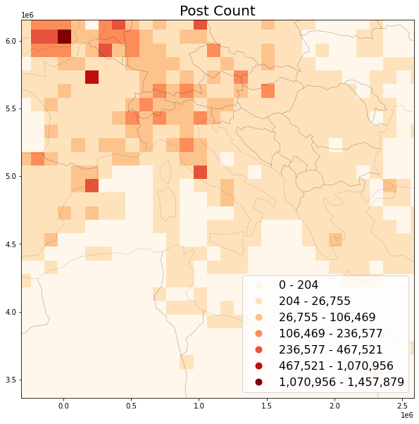

```python
save_plot(
    grid=grid, title='Post Count',
    column='postcount', save_fig='postcount_sample.png',
    bbox=bbox_italy, world=world)
```

## B: User Count per grid

When using RAW data, the caveat for calculating usercounts is that all distinct ids per bin must be present first, before calculating the total count. Since the input data (Social Media posts) is spatially unordered, this requires either a two-pass approach (e.g. writing intermediate data to disk and performing the count in a second pass), or storing all user guids per bin in-memory. We're using the second approach here.

What can be done to reduce memory load is to process the input data in *chunks*. After each chunk has been processed, Python's garbage collection can do its work and remove everything that is not needed anymore.

Furthermore, we can store intermediate data to CSV, which is also more efficient than loading data from DB.

These ideas are combined in the methods below. Adjust default chunk_size of `5000000` to your needs.

**Specify input data**

First, specify the columns that need to be retrieved from the database. In addition to lat and lng, we need the `user_guid` for calculating usercounts.

```python
usecols = ['latitude', 'longitude', 'user_guid']
```

Adjust method for stream-reading from CSV in chunks:

```python
%%time
iter_csv = pd.read_csv(
    OUTPUT / "csv" / "yfcc_posts.csv", usecols=usecols, iterator=True,
    dtype=dtypes, encoding='utf-8', chunksize=CHUNK_SIZE)
```

```
CPU times: user 2.22 ms, sys: 3.82 ms, total: 6.04 ms
Wall time: 5.19 ms
```

```python
def proj_report(df, cnt, inplace: bool = False):
    """Project df with progress report"""
    proj_df(df)
    clear_output(wait=True)
    print(f'Projected {cnt:,.0f} coordinates')
    if inplace:
        return
    return df
```

```python
%%time
# filter
chunked_df = [
    filter_df_bbox(
        df=chunk_df, bbox=bbox_italy_buf, inplace=False)
    for chunk_df in iter_csv]

# project
projected_cnt = 0
for chunk_df in chunked_df:
    projected_cnt += len(chunk_df)
    proj_report(
        chunk_df, projected_cnt, inplace=True)

display(chunked_df[0].head())
```

```
Projected 13,361,348 coordinates
```

|  | user_guid | x | y |
| --- | --- | --- | --- |
| 0 | 71322403@N00 | -31872.166464 | 4.731738e+06 |
| 1 | 22841923@N02 | 991046.755221 | 5.385474e+06 |
| 2 | 25622716@N02 | 901798.894258 | 5.677544e+06 |
| 3 | 84351449@N00 | 324299.385019 | 5.991327e+06 |
| 4 | 15181848@N02 | -114739.576009 | 6.127444e+06 |

```
CPU times: user 1min 18s, sys: 4.46 s, total: 1min 23s
Wall time: 1min 23s
```

### Perform the bin assignment and count distinct users

First assign coordinates to bin using our binary search:

```python
def bin_coordinates(
        df: pd.DataFrame, xbins:
        np.ndarray, ybins: np.ndarray) -> pd.DataFrame:
    """Bin coordinates using binary search and append to df as new index"""
    xbins_match, ybins_match = get_best_bins(
        search_values_x=df['x'].to_numpy(),
        search_values_y=df['y'].to_numpy(),
        xbins=xbins, ybins=ybins)
    # append target bins to original dataframe
    # use .loc to avoid chained indexing
    df.loc[:, 'xbins_match'] = xbins_match
    df.loc[:, 'ybins_match'] = ybins_match
    # drop x and y columns not needed anymore
    df.drop(columns=['x', 'y'], inplace=True)
```

```python
def bin_chunked_coordinates(
    chunked_df: List[pd.DataFrame], xbins:
    np.ndarray = XBINS, ybins: np.ndarray = YBINS):
    """Bin coordinates of chunked dataframe"""
    binned_cnt = 0
    for ix, df in enumerate(chunked_df):
        bin_coordinates(df, xbins, ybins)
        df.set_index(['xbins_match', 'ybins_match'], inplace=True)
        clear_output(wait=True)
        binned_cnt += len(df)
        print(f"Binned {binned_cnt:,.0f} coordinates..")
```

```python
%%time
bin_chunked_coordinates(chunked_df)
display(chunked_df[0].head())
```

```
Binned 13,361,348 coordinates..
```

| xbins_match | ybins_match | user_guid |
| --- | --- | --- |
| -40096 | 4779952 | 71322403@N00 |
| 959904 | 5479952 | 22841923@N02 |
| 859904 | 5679952 | 25622716@N02 |
| 259904 | 6079952 | 84351449@N00 |
| -140096 | 6179952 | 15181848@N02 |

```
CPU times: user 6.98 s, sys: 317 ms, total: 7.29 s
Wall time: 7.19 s
```

Now group user_guids per bin in distinct sets. The demonstration below is based the first chunk of posts (`[0]`):

```python
%%time
df = chunked_df[0]
series_grouped = df["user_guid"].groupby(
        df.index).apply(set)
series_grouped.head()
```

```
CPU times: user 4.72 s, sys: 531 ms, total: 5.25 s
Wall time: 5.13 s
```

```
(-340096, 4279952)    {75315636@N00, 785589...
(-340096, 4479952)    {75315636@N00, 140161...
(-340096, 4579952)    {75315636@N00, 140161...
(-340096, 4679952)    {75315636@N00, 280791...
(-340096, 4779952)    {7183730@N06, 1871975...
Name: user_guid, dtype: object
```

Now we have sets of user_guids per bin. The next step is to count the number of distinct items in each set:

```python
%%time
cardinality_series = series_grouped.apply(len)
cardinality_series.head()
```

```
CPU times: user 1.34 ms, sys: 123 µs, total: 1.47 ms
Wall time: 1.41 ms
```

```
(-340096, 4279952)    19
(-340096, 4479952)    84
(-340096, 4579952)    79
(-340096, 4679952)    32
(-340096, 4779952)    47
Name: user_guid, dtype: int64
```

To be able to process all user_guids in chunks, we need to union sets incrementally and, finally, attach distinct user count to grid, based on composite index (bin-ids). This last part of the process is the same as in counting posts.

```python
def init_col_emptysets(
    grid: Union[pd.DataFrame, gp.GeoDataFrame], col_name: str):
    """Initialize column of dataframe with empty sets."""
    grid[col_name] = [set() for x in range(len(grid.index))]
```

```python
def union_sets_series(
    set_series: pd.Series, set_series_other: pd.Series) -> pd.Series:
    """Union of two pd.Series of sets based on index, with keep set index"""
    return pd.Series(
        [set.union(*z) for z in zip(set_series, set_series_other)],
        index=set_series.index)

def group_union_chunked(
    chunked_df: List[pd.DataFrame], grid: gp.GeoDataFrame,
    col: str = "user_guid", metric: str = "usercount", drop_sets: bool = None,
    chunk_size: int = CHUNK_SIZE):
    """Group dataframe records per bin, create distinct sets,
    calculate cardinality and append to grid"""
    if drop_sets is None:
        drop_sets = True
    # init grid empty sets
    init_col_emptysets(grid, f"{metric}_set")
    for ix, df in enumerate(chunked_df):
        series_grouped = df[col].groupby(
            df.index).apply(set)
        # series of new user_guids per bin
        series_grouped.index = pd.MultiIndex.from_tuples(
            series_grouped.index, names=['xbin', 'ybin'])
        # series of existing user_guids per bin
        existing_sets_series = grid.loc[
            series_grouped.index, f"{metric}_set"]
        # union existing & new
        series_grouped = union_sets_series(
            series_grouped, existing_sets_series)
        grid.loc[series_grouped.index, f'{metric}_set'] = series_grouped
        clear_output(wait=True)
        print(f"Grouped {(ix*chunk_size)+len(df):,.0f} {col}s..")

    # after all user_guids have been processed to bins,
    # calculate cardinality and drop user_guids to free up memory
    grid[metric] = grid[f'{metric}_set'].apply(len)
    if drop_sets:
        grid.drop(columns=[f'{metric}_set'], inplace=True)
```

```python
%%time
group_union_chunked(
    chunked_df=chunked_df, grid=grid,
    col="user_guid", metric="usercount")
grid[grid["usercount"]> 0].head()
```

```
Grouped 45,793,148 user_guids..
CPU times: user 44.8 s, sys: 1.06 s, total: 45.9 s
Wall time: 45.7 s
```

| xbin | ybin | geometry | postcount | usercount |
| --- | --- | --- | --- | --- |
| -340096 | 6179952 | POLYGON ((-340096.000... | 771 | 68 |
|  | 6079952 | POLYGON ((-340096.000... | 12990 | 520 |
|  | 5979952 | POLYGON ((-340096.000... | 5075 | 234 |
|  | 5879952 | POLYGON ((-340096.000... | 1 | 1 |
|  | 5779952 | POLYGON ((-340096.000... | 1521 | 148 |

### Preview user count map

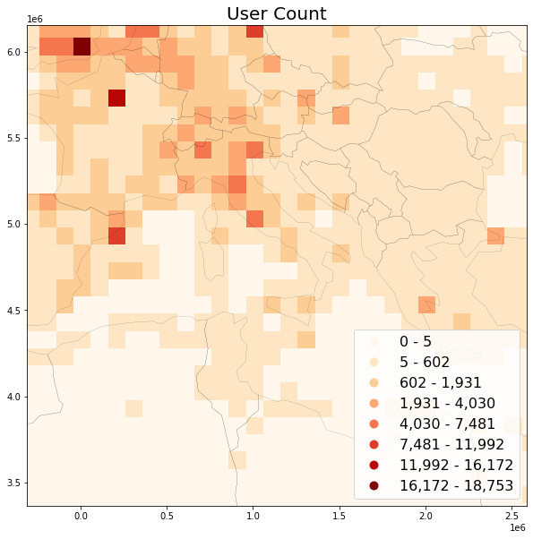

```python
save_plot(
    grid=grid, title='User Count',
    column='usercount', save_fig='usercount_sample.png',
    bbox=bbox_italy, world=world)
```

## C: User Days

Wood, Guerry, Silver and Lacayo (2013) found that frequency of Flickr users per month correlates with official visitation rates for National Parks in the USA and further coined the term “user days” as a measurement for “the total number of days, across all users, that each person took at least one photograph within each site” (ibid, p. 6). User days has emerged as a suitable intermediate metric, between post count and user count.

To calculate user days, we need to query additional YFCC post attribute `post_create_date`. This requires overriding `usecols` list:

```python
usecols = ['latitude', 'longitude', 'user_guid', 'post_create_date']
```

Get data from CSV (define a method this time):

```python
def read_project_chunked(filename: str,
    usecols: List[str], chunk_size: int = CHUNK_SIZE,
    bbox: Tuple[float, float, float, float] = None) -> List[pd.DataFrame]:
    """Read data from csv, optionally clip to bbox and projet"""
    iter_csv = pd.read_csv(
        filename, usecols=usecols, iterator=True,
        dtype=dtypes, encoding='utf-8', chunksize=chunk_size)
    if bbox:
        chunked_df = [filter_df_bbox(
            df=chunk_df, bbox=bbox, inplace=False)
        for chunk_df in iter_csv]
    else:
        chunked_df = [chunk_df for chunk_df in iter_csv]
    # project
    projected_cnt = 0
    for chunk_df in chunked_df:
        projected_cnt += len(chunk_df)
        proj_report(
            chunk_df, projected_cnt, inplace=True)
    return chunked_df
```

Run:

```python
%%time
chunked_df = read_project_chunked(
    filename=OUTPUT / "csv" / "yfcc_posts.csv",
    usecols=usecols,
    bbox=bbox_italy_buf)
display(chunked_df[0].head())
```

```
Projected 13,361,348 coordinates
```

|  | user_guid | post_create_date | x | y |
| --- | --- | --- | --- | --- |
| 0 | 71322403@N00 | 2009-06-20 | -31872.166464 | 4.731738e+06 |
| 1 | 22841923@N02 | 2004-08-15 | 991046.755221 | 5.385474e+06 |
| 2 | 25622716@N02 | 2007-07-09 | 901798.894258 | 5.677544e+06 |
| 3 | 84351449@N00 | 2012-07-07 | 324299.385019 | 5.991327e+06 |
| 4 | 15181848@N02 | 2009-01-24 | -114739.576009 | 6.127444e+06 |

```
CPU times: user 1min 34s, sys: 5.53 s, total: 1min 39s
Wall time: 1min 39s
```

```python
%%time
bin_chunked_coordinates(chunked_df)
```

```
Binned 13,361,348 coordinates..
CPU times: user 7.07 s, sys: 54.8 ms, total: 7.12 s
Wall time: 7.06 s
```

```python
chunked_df[0].head()
```

| xbins_match | ybins_match | user_guid | post_create_date |
| --- | --- | --- | --- |
| -40096 | 4779952 | 71322403@N00 | 2009-06-20 |
| 959904 | 5479952 | 22841923@N02 | 2004-08-15 |
| 859904 | 5679952 | 25622716@N02 | 2007-07-09 |
| 259904 | 6079952 | 84351449@N00 | 2012-07-07 |
| -140096 | 6179952 | 15181848@N02 | 2009-01-24 |

To count distinct userdays, concat user_guid and post_create_date into single column:

```python
%%time
def concat_cols_df(
    df: pd.DataFrame, col1: str, col2: str, col_out: str):
    """Concat dataframe values of col1 and col2 into new col"""
    df[col_out] = df[col1] + df[col2]
    df.drop(columns=[col1, col2], inplace=True)
```

```
CPU times: user 11 µs, sys: 0 ns, total: 11 µs
Wall time: 17.4 µs
```

```python
%%time
for df in chunked_df:
    concat_cols_df(
        df, col1="user_guid",
        col2="post_create_date",
        col_out="user_day")
chunked_df[0].head()
```

```
CPU times: user 13.2 s, sys: 575 ms, total: 13.8 s
Wall time: 13.8 s
```

| xbins_match | ybins_match | user_day |
| --- | --- | --- |
| -40096 | 4779952 | 71322403@N002009-06-20 |
| 959904 | 5479952 | 22841923@N022004-08-15 |
| 859904 | 5679952 | 25622716@N022007-07-09 |
| 259904 | 6079952 | 84351449@N002012-07-07 |
| -140096 | 6179952 | 15181848@N022009-01-24 |

Count distinct userdays and attach counts to grid. The process is now the same as in counting distinct users:

```python
%%time
group_union_chunked(
    chunked_df=chunked_df, grid=grid,
    col="user_day", metric="userdays")
display(grid[grid["userdays"]> 0].head())
```

```
Grouped 45,793,148 user_days..
```

| xbin | ybin | geometry | postcount | usercount | userdays |
| --- | --- | --- | --- | --- | --- |
| -340096 | 6179952 | POLYGON ((-340096.000... | 771 | 68 | 163 |
|  | 6079952 | POLYGON ((-340096.000... | 12990 | 520 | 2550 |
|  | 5979952 | POLYGON ((-340096.000... | 5075 | 234 | 792 |
|  | 5879952 | POLYGON ((-340096.000... | 1 | 1 | 1 |
|  | 5779952 | POLYGON ((-340096.000... | 1521 | 148 | 351 |

```
CPU times: user 1min 27s, sys: 1.24 s, total: 1min 28s
Wall time: 1min 27s
```

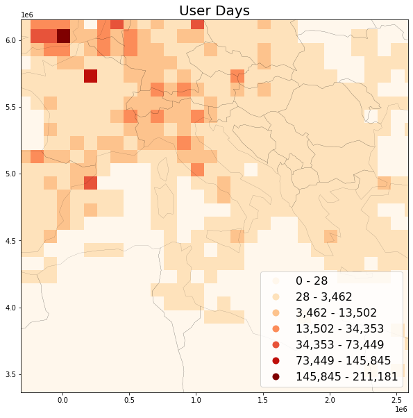

```python
save_plot(
    grid=grid, title='User Days',
    column='userdays', save_fig='userdays_sample.png',
    bbox=bbox_italy, world=world)
```

# Prepare methods

Lets summarize the above code in a few methods:

```python
def group_count(
    df: pd.DataFrame) -> pd.Series:
    """Group dataframe by composite index and return count of duplicate indexes

    Args:
       df: Indexed dataframe (with duplicate indexes).
    """
    series_grouped = df.groupby(
            df.index).size()
    # split tuple index to produce
    # the multiindex of the original dataframe
    # with xbin and ybin column names
    series_grouped.index = pd.MultiIndex.from_tuples(
        series_grouped.index, names=['xbin', 'ybin'])
    # return column as indexed pd.Series
    return series_grouped
```

**Plotting preparation**

The below methods contain combined code from above, plus final plot style improvements.

```python
def format_legend(
    leg, bounds: List[str], inverse: bool = None,
    metric: str = "postcount"):
    """Formats legend (numbers rounded, colors etc.)"""
    leg.set_bbox_to_anchor((0., 0.2, 0.2, 0.2))
    # get all the legend labels
    legend_labels = leg.get_texts()
    plt.setp(legend_labels, fontsize='12')
    lcolor = 'black'
    if inverse:
        frame = leg.get_frame()
        frame.set_facecolor('black')
        frame.set_edgecolor('grey')
        lcolor = "white"
    plt.setp(legend_labels, color = lcolor)
    if metric == "postcount":
        leg.set_title("Post Count")
    elif metric == "usercount":
        leg.set_title("User Count")
    else:
        leg.set_title("User Days")
    plt.setp(leg.get_title(), fontsize='12')
    leg.get_title().set_color(lcolor)
    # replace the numerical legend labels
    for bound, legend_label in zip(bounds, legend_labels):
        legend_label.set_text(bound)
```

```python
def format_bound(
    upper_bound: float = None, lower_bound: float = None) -> str:
    """Format legend text for class bounds"""
    if upper_bound is None:
        return f'{lower_bound:,.0f}'
    if lower_bound is None:
        return f'{upper_bound:,.0f}'
    return f'{lower_bound:,.0f} - {upper_bound:,.0f}'

def get_label_bounds(
    scheme_classes, metric_series: pd.Series,
    flat: bool = None) -> List[str]:
    """Get all upper bounds in the scheme_classes category"""
    upper_bounds = scheme_classes.bins
    # get and format all bounds
    bounds = []
    for idx, upper_bound in enumerate(upper_bounds):
        if idx == 0:
            lower_bound = metric_series.min()
        else:
            lower_bound = upper_bounds[idx-1]
        if flat:
            bound = format_bound(
                lower_bound=lower_bound)
        else:
            bound = format_bound(
                upper_bound, lower_bound)
        bounds.append(bound)
    if flat:
        upper_bound = format_bound(
            upper_bound=upper_bounds[-1])
        bounds.append(upper_bound)
    return bounds

def label_nodata(
    grid: gp.GeoDataFrame, inverse: bool = None,
    metric: str = "postcount"):
    """Add white to a colormap to represent missing value

    Adapted from:
        https://stackoverflow.com/a/58160985/4556479

    See available colormaps:
        http://holoviews.org/user_guide/Colormaps.html
    """
    # set 0 to NaN
    grid_nan = grid[metric].replace(0, np.nan)
    # get headtail_breaks
    # excluding NaN values
    headtail_breaks = mc.HeadTailBreaks(
        grid_nan.dropna())
    grid[f'{metric}_cat'] = headtail_breaks.find_bin(
        grid_nan).astype('str')
    # set label for NaN values
    grid.loc[grid_nan.isnull(), f'{metric}_cat'] = 'No Data'
    bounds = get_label_bounds(
        headtail_breaks, grid_nan.dropna().values)
    cmap_name = 'OrRd'
    nodata_color = 'white'
    if inverse:
        nodata_color = 'black'
        cmap_name = 'cet_fire'
    cmap = plt.cm.get_cmap(cmap_name, headtail_breaks.k)
    # get hex values
    cmap_list = [colors.rgb2hex(cmap(i)) for i in range(cmap.N)]
    # lighten or darken up first/last color a bit
    # to offset from black or white background
    if inverse:
        firstcolor = '#3E0100'
        cmap_list[0] = firstcolor
    else:
        lastcolor = '#440402'
        cmap_list.append(lastcolor)
        cmap_list.pop(0)
    # append nodata color
    cmap_list.append(nodata_color)
    cmap_with_nodata = colors.ListedColormap(cmap_list)
    return cmap_with_nodata, bounds

def plot_figure(
    grid: gp.GeoDataFrame, title: str, inverse: bool = None,
    metric: str = "postcount", store_fig: str = None,
    output: Path = OUTPUT):
    """Combine layers and plot"""
    # for plotting, there're some minor changes applied
    # to the dataframe (replace NaN values),
    # make a shallow copy here to prevent changes
    # to modify the original grid
    grid_plot = grid.copy()
    # create new plot figure object with one axis
    fig, ax = plt.subplots(1, 1, figsize=(22,28))
    ax.set_title(title, fontsize=16)
    print("Classifying bins..")
    cmap_with_nodata, bounds = label_nodata(
        grid=grid_plot, inverse=inverse, metric=metric)
    base = grid_plot.plot(
        ax=ax,
        column=f'{metric}_cat', cmap=cmap_with_nodata, legend=True)
    leg = ax.get_legend()
    print("Formatting legend..")
    format_legend(leg, bounds, inverse, metric)
    # combine with world geometry
    edgecolor = 'black'
    if inverse:
        edgecolor = 'white'
    world = gp.read_file(
            gp.datasets.get_path('naturalearth_lowres'), crs=CRS_WGS)
    world = world.to_crs(CRS_PROJ)
    plot = world.plot(
        ax=base, color='none', edgecolor=edgecolor, linewidth=0.1)
    if store_fig:
        print("Storing figure as png..")
        if inverse:
            store_fig = store_fig.replace('.png', '_inverse.png')
        plot.get_figure().savefig(
            output / "figures" / store_fig, dpi=300, format='PNG',
            bbox_inches='tight', pad_inches=1)
```

```python
def filter_nullisland_df(
    df: Optional[pd.DataFrame] = None, df_list: Optional[List[pd.DataFrame]] = None,
    col_x: str = "longitude", col_y: str = "latitude"):
    """Remove records from df inplace where both x and y coordinate are 0"""
    if not df is None:
        df_list = [df]
    if not df_list:
        raise ValueError("Please provide either df or df_list")
    for df in df_list:
        if col_x in df.columns:
            df.query(
                f'({col_x} == 0 and {col_y} == 0) == False',
                inplace=True)

def load_plot(
    filename: str, grid: gp.GeoDataFrame, title: str, inverse: bool = None,
    metric: str = "postcount", store_fig: str = None, store_pickle: str = None,
    chunk_size: int = CHUNK_SIZE, drop_sets: bool = None, output: Path = OUTPUT):
    """Load data, bin coordinates, estimate distinct counts (cardinality) and plot map

        Args:
        filename: Filename to read and write intermediate data
        grid: A geopandas geodataframe with indexes x and y
            (projected coordinates) and grid polys
        title: Title of the plot
        inverse: If True, inverse colors (black instead of white map)
        metric: target column for aggregate. Default: postcount_est.
        store_fig: Provide a name to store figure as PNG. Will append
            '_inverse.png' if inverse=True.
        store_pickle: Provide a name to store pickled dataframe
            with aggregate counts to disk
        chunk_size: chunk processing into x records per chunk
        drop_sets: After count of distinct ids, drop sets per bin,
            to free up memory. Default: None/True
    """
    usecols = ['latitude', 'longitude']
    if metric != "postcount":
        usecols.append('user_guid')
    if metric == "userdays":
        usecols.append('post_create_date')
    # get data from CSV
    chunked_df = read_project_chunked(
        filename=output / "csv" / filename,
        usecols=usecols)
    # bin coordinates
    bin_chunked_coordinates(chunked_df)
    # reset metric column
    reset_metrics(grid, [metric], setzero=True)
    print("Getting cardinality per bin..")
    if metric == "postcount":
        cardinality_cnt = 0
        for df in chunked_df:
            cardinality_series = group_count(
                df)
            # update postcounts per grid-bin based on index,
            # use += to allow incremental update
            grid.loc[
                cardinality_series.index,
                'postcount'] += cardinality_series
            cardinality_cnt += len(df)
            clear_output(wait=True)
            print(f"{cardinality_cnt:,.0f} posts processed.")
    else:
        col = "user_guid"
        if metric == "userdays":
            # concat user_guid and
            # post_create_date
            for df in chunked_df:
                concat_cols_df(
                    df, col1="user_guid",
                    col2="post_create_date",
                    col_out="user_day")
            col = "user_day"
        group_union_chunked(
            chunked_df=chunked_df, grid=grid,
            col=col, metric=metric, drop_sets=drop_sets)
    print("Storing aggregate data as pickle..")
    if store_pickle:
        grid.to_pickle(output / "pickles" / store_pickle)
    print("Plotting figure..")
    plot_figure(grid, title, inverse, metric, store_fig)
```

# Plotting worldmaps: Post Count, User Count and User Days

Plot worldmap for each datasource

```python
reset_metrics(grid, ["postcount", "usercount", "userdays"])
```

```
47,843,599 posts processed.
Storing aggregate data as pickle..
Plotting figure..
Classifying bins..
Formatting legend..
Storing figure as png..
peak memory: 11313.71 MiB, increment: 6889.32 MiB
CPU times: user 6min 11s, sys: 31.9 s, total: 6min 43s
Wall time: 6min 41s
```

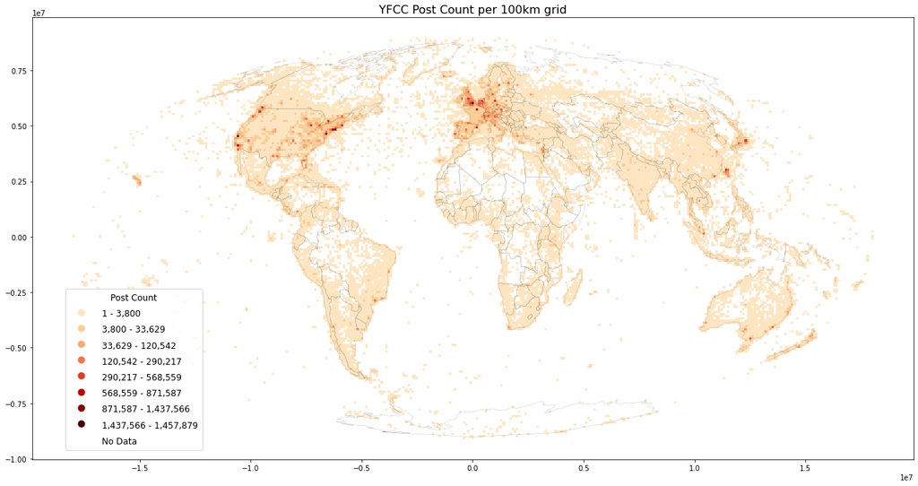

```python
%%time
%%memit
load_plot(
    grid=grid, filename='yfcc_posts.csv', title=f'YFCC Post Count per {int(GRID_SIZE_METERS/1000)}km grid',
    inverse=False, store_fig="yfcc_postcount.png", drop_sets=False)
```

```
Grouped 47,843,599 user_guids..
Storing aggregate data as pickle..
Plotting figure..
Classifying bins..
Formatting legend..
Storing figure as png..
peak memory: 12630.22 MiB, increment: 8194.15 MiB
CPU times: user 9min 25s, sys: 59.6 s, total: 10min 24s
Wall time: 11min 4s
```

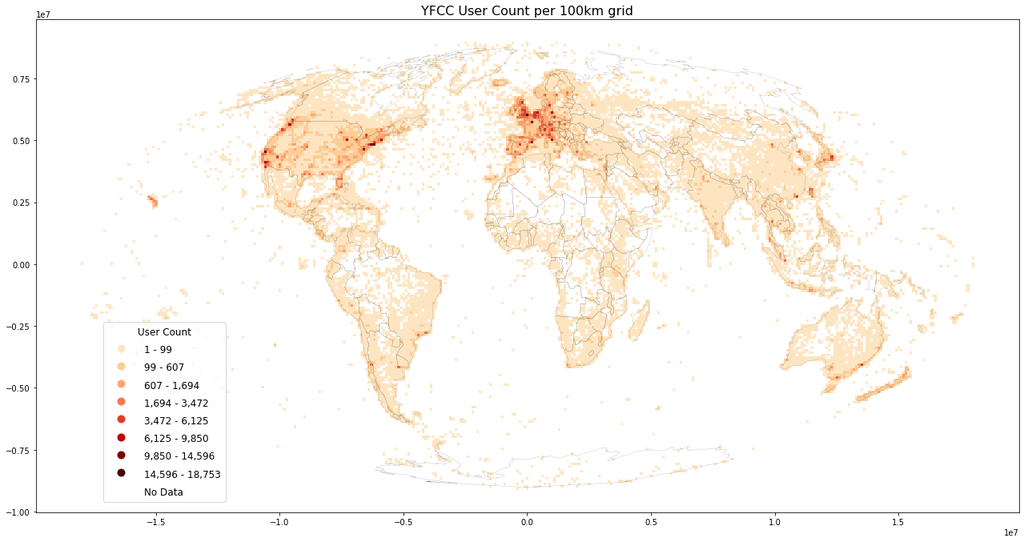

```python
%%time
%%memit
load_plot(
    grid=grid, filename='yfcc_posts.csv', title=f'YFCC User Count per {int(GRID_SIZE_METERS/1000)}km grid',
    inverse=False, store_fig="yfcc_usercount.png",
    metric="usercount", drop_sets=False)
```

```
Grouped 47,843,599 user_days..
Storing aggregate data as pickle..
Plotting figure..
Classifying bins..
Formatting legend..
Storing figure as png..
peak memory: 16218.47 MiB, increment: 10684.51 MiB
CPU times: user 14min 36s, sys: 53.2 s, total: 15min 29s
Wall time: 15min 28s
```

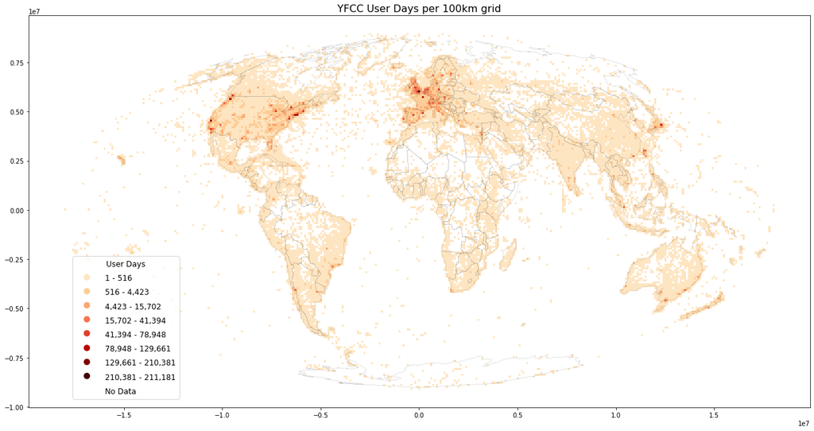

```python
%%time
%%memit
load_plot(
    grid=grid, filename='yfcc_posts.csv', title=f'YFCC User Days per {int(GRID_SIZE_METERS/1000)}km grid',
    inverse=False, store_fig="yfcc_userdays.png",
    metric="userdays", drop_sets=False)
```

Have a look at the final `grid` with cardinality (distinct counts) for postcount, usercount and userdays

An immediate validation is to verify that `postcount` >= `userdays` >= `usercount`.

```python
grid[grid["postcount"]>1].head()
```

| xbin | ybin | geometry | postcount | usercount | usercount_set | userdays | userdays_set |
| --- | --- | --- | --- | --- | --- | --- | --- |
| -18040096 | 79952 | POLYGON ((-18040096.0... | 7 | 2 | {26105073@N03, 341979... | 7 | {26105073@N031986-12-... |
| -17640096 | -2020048 | POLYGON ((-17640096.0... | 634 | 19 | {59171457@N00, 212490... | 67 | {71990437@N032011-10-... |
| -17540096 | -2020048 | POLYGON ((-17540096.0... | 54 | 2 | {71990437@N03, 101884... | 11 | {71990437@N032011-10-... |
|  | -2120048 | POLYGON ((-17540096.0... | 3 | 1 | {67439103@N00} | 1 | {67439103@N001996-11-01} |
| -17440096 | -1620048 | POLYGON ((-17440096.0... | 4 | 2 | {72898690@N00, 258164... | 4 | {72898690@N002019-04-... |

# Save & load intermediate data

## Load & store results from and to CSV

To export only aggregate counts (postcount, usercount) to CSV (e.g. for archive purposes):

**Store results to CSV for archive purposes:**

Define method

```python
def grid_agg_tocsv(
    grid: gp.GeoDataFrame, filename: str,
    metrics: List[str] = ["postcount", "usercount", "userdays"],
    output: Path = OUTPUT):
    """Store geodataframe aggregate columns and indexes to CSV"""
    grid.to_csv(output / "csv" / filename, mode='w', columns=metrics, index=True)
```

Convert/store to CSV (aggregate columns and indexes only):

```python
grid_agg_tocsv(grid, "yfcc_all_raw.csv")
```

**Store results as benchmark data (with sets):**

Internal database scenario

```python
grid_agg_tocsv(
    grid, "yfcc_all_raw_benchmark.csv",
    metrics = ["usercount_set", "userdays_set",
               "usercount", "postcount", "userdays"])
```

Size of benchmark data:

```python
benchmark_size_mb = Path(OUTPUT / "csv" / "yfcc_all_raw_benchmark.csv").stat().st_size / (1024*1024)
print(f"Size: {benchmark_size_mb:.2f} MB")
```

```
Size: 182.46 MB
```

**Load data from CSV:**

```python
def create_new_grid(grid_size: int = GRID_SIZE_METERS,
    proj_transformer: Transformer = PROJ_TRANSFORMER) -> gp.GeoDataFrame:
    """Create new 100x100km grid GeoDataFrame with custom projection"""
    xmin = proj_transformer.transform(
        -180, 0)[0]
    xmax = proj_transformer.transform(
        180, 0)[0]
    ymax = proj_transformer.transform(
        0, 90)[1]
    ymin = proj_transformer.transform(
        0, -90)[1]
    grid = create_grid_df(
        grid_size=grid_size,
        xmin=xmin, ymin=ymin,
        xmax=xmax, ymax=ymax)
    # convert grid DataFrame to grid GeoDataFrame
    grid = grid_to_gdf(grid)
    return grid

def grid_agg_fromcsv(
    filename: str, columns: List[str] = ["xbin", "ybin"],
    metrics: List[str] = None, grid_size: int = GRID_SIZE_METERS):
    """Create a new Mollweide grid GeoDataFrame and
    attach aggregate data columns from CSV based on index"""
    # 1. Create new 100x100km (e.g.) grid
    grid = create_new_grid(grid_size=grid_size)
    # 2. load aggregate data from CSV and attach to grid
    # -----
    if metrics is None:
        metrics = ["postcount", "usercount", "userdays"]
    types_dict = dict()
    for metric in metrics:
        types_dict[metric] = int
    columns = columns + metrics
    df = pd.read_csv(
        filename, dtype=types_dict, index_col=["xbin", "ybin"],
        usecols=columns)
    # join columns based on index
    grid = grid.join(df)
    # return grid with aggregate data attached
    return grid
```

To create a new grid and load aggregate counts from CSV:

```python
grid = grid_agg_fromcsv(
    OUTPUT / "csv" / "yfcc_all_raw.csv")
```

## Load & plot pickled dataframe

Loading (geodataframe) using pickle. This is the easiest way to store intermediate data, but may be incompatible [if package versions change](https://stackoverflow.com/questions/6687262/how-do-i-know-which-versions-of-pickle-a-particular-version-of-python-supports). If loading pickles does not work, a workaround is to load data from CSV and re-create pickle data, which will be compatible with used versions.

**Store results using pickle for later resuse:**

```python
grid.to_pickle(OUTPUT / "pickles" / "yfcc_all_raw.pkl")
```

**Load pickled dataframe:**

```python
%%time
grid = pd.read_pickle(OUTPUT / "pickles" / "yfcc_all_raw.pkl")
```

```
CPU times: user 1.46 s, sys: 0 ns, total: 1.46 s
Wall time: 1.47 s
```

Then use plot_figure on dataframe to plot with new parameters, e.g. plot inverse:

```
Classifying bins..
Formatting legend..
```

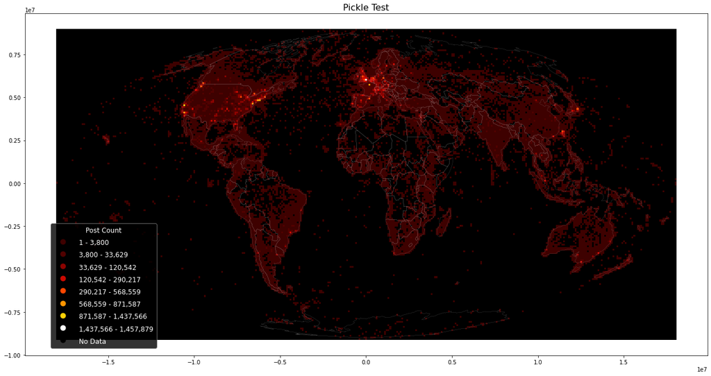

```python
plot_figure(grid, "Pickle Test", inverse=True, metric="postcount")
```

# Close DB connection & Create notebook HTML

```python
db_connection.close()
```

```python
!jupyter nbconvert --to html_toc \
    --output-dir=../out/html ./02_yfcc_gridagg_raw.ipynb \
    --template=../nbconvert.tpl \
    --ExtractOutputPreprocessor.enabled=False # create single output file
```

```
[NbConvertApp] Converting notebook ./02_yfcc_gridagg_raw.ipynb to html_toc
[NbConvertApp] Writing 2069823 bytes to ../out/html/02_yfcc_gridagg_raw.html
```

In the hll notebook, we'll create the same visuals using the privacy-aware hll version of the dataset. Follow in 03_yfcc_gridagg_hll.ipynb